# 2022 Rating Curves

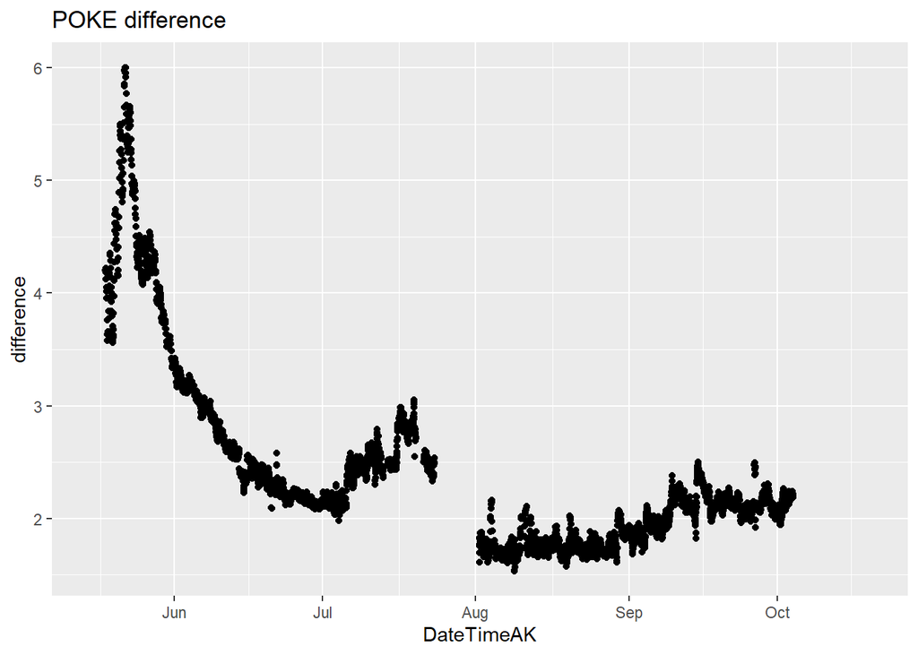

```r
# Plot difference
POKE.2022 %>% filter(DateTimeAK > "2022-05-15") %>%
  ggplot(aes(DateTimeAK, difference)) + geom_point() +
  ggtitle("POKE difference")
```

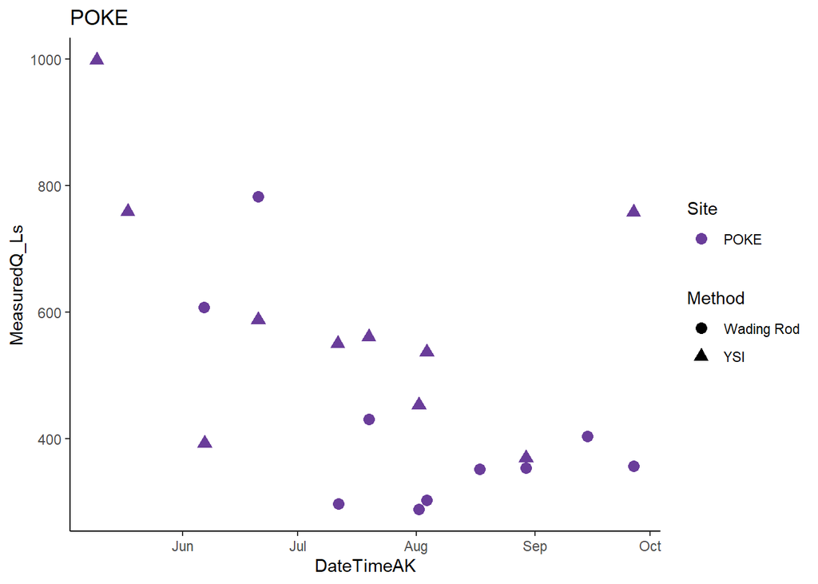

```r
### Filter POKE ###
QSummary.PO.2022 <- QSummary.2022 %>% filter(Site =="POKE")

ggplot(QSummary.PO.2022) +
  geom_point(aes(x = DateTimeAK, y = MeasuredQ_Ls, shape = Method, color = Site), size=3) +
  theme_classic() +
  scale_color_manual(values=c("#6A3D9A")) +
  ggtitle("POKE")
```

```r
# Merge by nearest date if we have an offset point
POKE.2022.dt <- setDT(POKE.2022) %>% filter(!difference %in% NA)
QSummary.PO.2022.dt <- QSummary.PO.2022 %>% filter(DateTimeAK > "2022-05-17")

Poker1comb.2022 <- POKE.2022.dt[QSummary.PO.2022.dt, on = "DateTimeAK", roll = 'nearest']
```

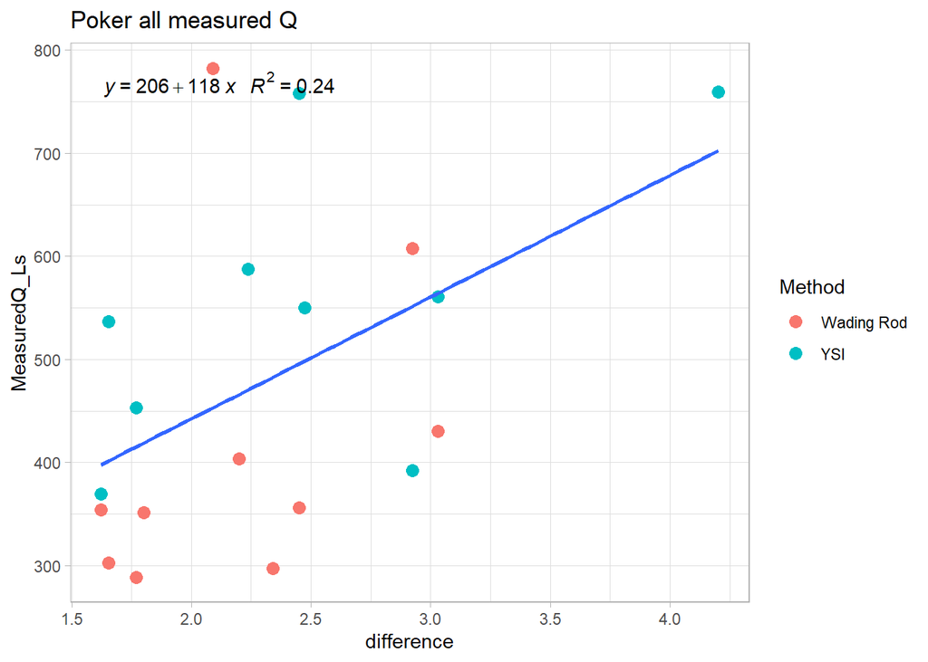

```r
### Rating Curve ###
poke.formula <- y ~ x
ggplot(aes(x = difference, y = MeasuredQ_Ls), data = Poker1comb.2022) +
  geom_point(aes(color = Method), size = 3) +
  geom_smooth(method = "lm", se=FALSE, formula = poke.formula) +
  stat_poly_eq(formula = poke.formula,
               aes(label = paste(..eq.label.., ..rr.label.., sep = "~~~")),
               parse = TRUE) +
  theme_light() +
  ggtitle("Poker all measured Q")
```

This is the rating curve. We are missing 5/9 and 5/17 YSI because we didn’t have our Pressure Transducers in yet.

I am not sure what is going on here. I plotted every single pressure point that is matched with a Q measurement and they all look reasonable/are not outliers.

I will remove two points.

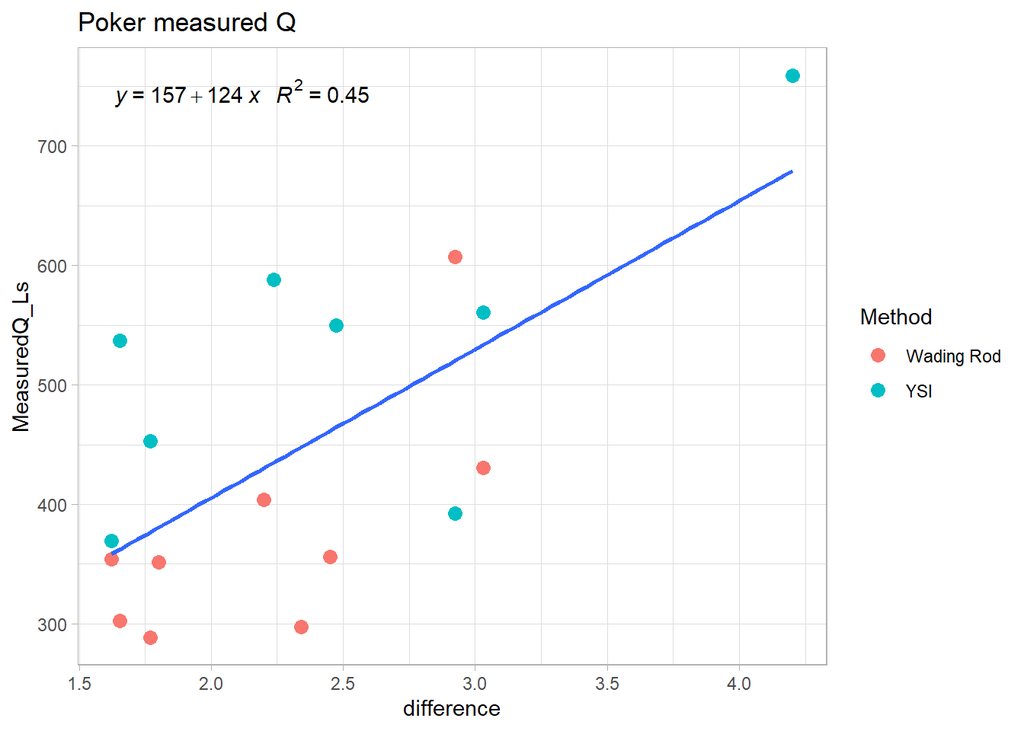

```r
# Remove two high Q points points
Poker1comb.2022.2 <- Poker1comb.2022 %>% filter(MeasuredQ_Ls < 700 | difference > 4)
### Rating Curve ###
poke.formula <- y ~ x
ggplot(aes(x = difference, y = MeasuredQ_Ls), data = Poker1comb.2022.2) +
  geom_point(aes(color = Method), size = 3) +
  geom_smooth(method = "lm", se=FALSE, formula = poke.formula) +
  stat_poly_eq(formula = poke.formula,
               aes(label = paste(..eq.label.., ..rr.label.., sep = "~~~")),
               parse = TRUE) +
  theme_light() +
  ggtitle("Poker measured Q")
```

I will try curves for just wading rod with quadratic relationship.

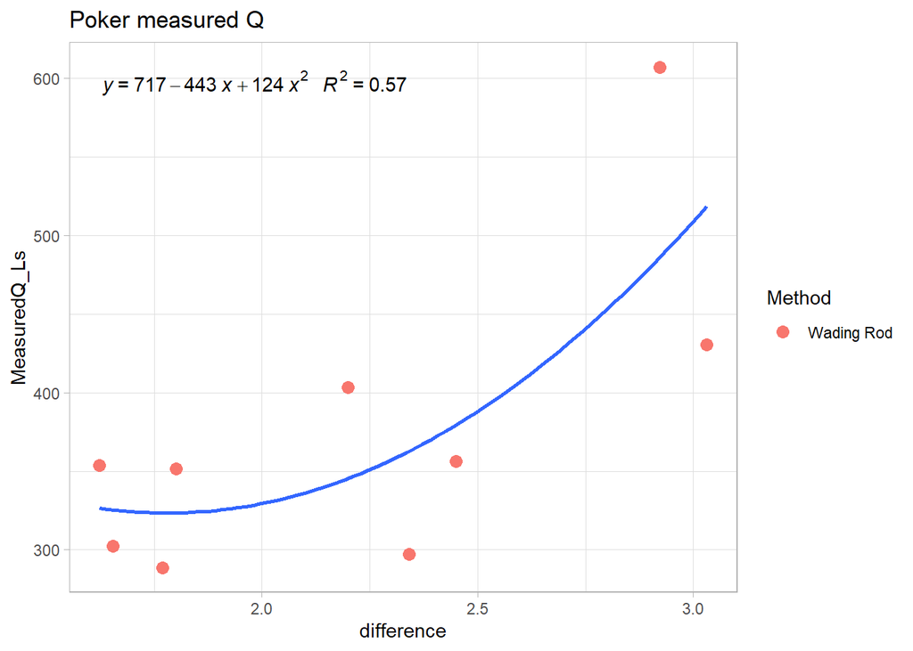

```r
### Rating Curve ###
poke.formula <- y ~ poly(x, 2, raw = TRUE)
Poker1comb.2022.2 %>% filter(Method == "Wading Rod") %>% ggplot(aes(x = difference, y = MeasuredQ_Ls)) +
  geom_point(aes(color = Method), size = 3) +
  geom_smooth(method = "lm", se=FALSE, formula = poke.formula) +
  stat_poly_eq(formula = poke.formula,
               aes(label = paste(..eq.label.., ..rr.label.., sep = "~~~")),
               parse = TRUE) +
  theme_light() +
  ggtitle("Poker measured Q")
```

Should we add a few YSI points back in?

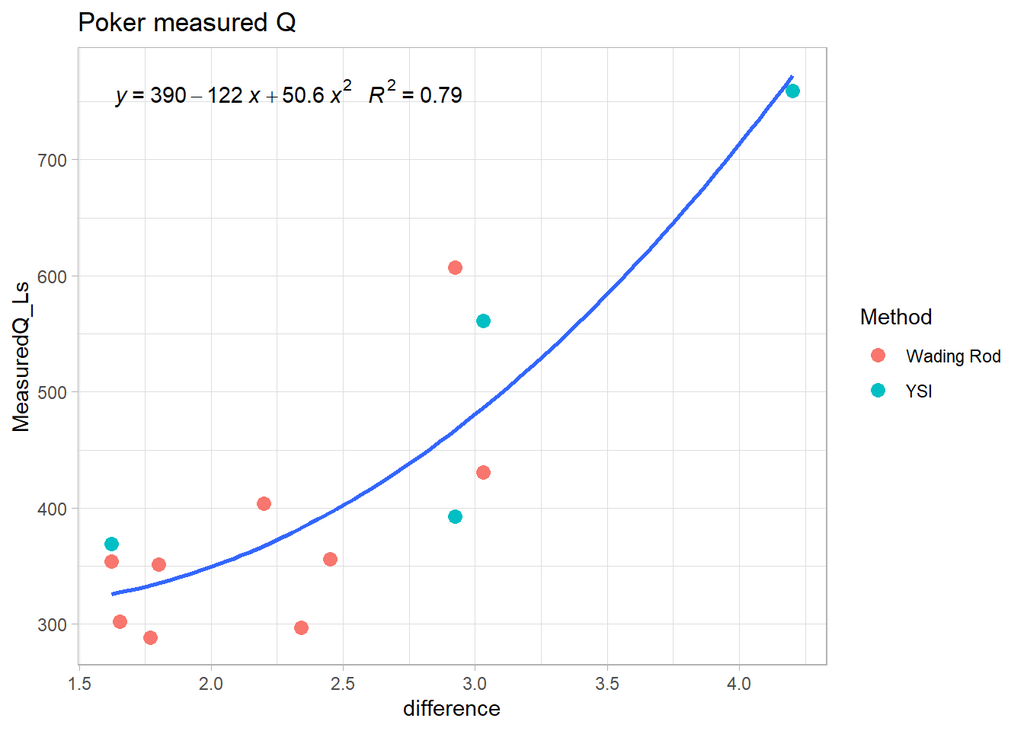

```r
### Rating Curve ###

poke.formula <- y ~ poly(x, 2, raw = TRUE)
Poker1comb.2022.3 <- Poker1comb.2022.2 %>% filter(difference > 2.5 | MeasuredQ_Ls < 450)
Poker1comb.2022.3 %>% ggplot(aes(x = difference, y = MeasuredQ_Ls)) +
  geom_point(aes(color = Method), size = 3) +
  geom_smooth(method = "lm", se=FALSE, formula = poke.formula) +
  stat_poly_eq(formula = poke.formula,
               aes(label = paste(..eq.label.., ..rr.label.., sep = "~~~")),
               parse = TRUE) +
  theme_light() +
  ggtitle("Poker measured Q")
```

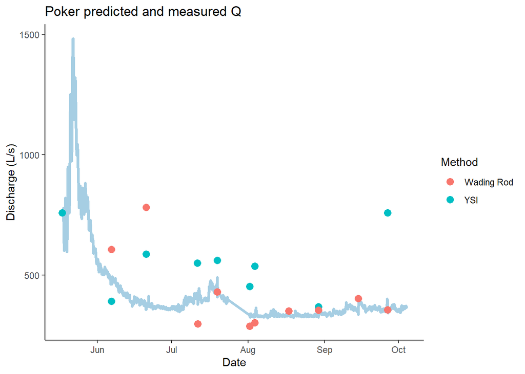

```r
## Predict POKE Q
POKE1.lm.2022 <- lm(Poker1comb.2022.3$MeasuredQ_Ls ~ Poker1comb.2022.3$difference + I(Poker1comb.2022.3$difference^2))


POKE.2022.dt$pred.poke.Q <- coef(POKE1.lm.2022)[2] * POKE.2022.dt$difference + I(coef(POKE1.lm.2022)[3] * POKE.2022.dt$difference^2)+coef(POKE1.lm.2022)[1]

POKE.2022.dt <- POKE.2022.dt %>% select(DateTimeAK, pred.poke.Q)
POKE.2022.dt <- na_kalman(POKE.2022.dt)

POKE.2022.dt %>% na.omit() %>% ggplot(aes(x = DateTimeAK, y = pred.poke.Q)) +
  geom_line(color="#A6CEE3", size=1.25) +
  geom_point(data = Poker1comb.2022, aes(x = DateTimeAK, y = MeasuredQ_Ls, color = Method), size=3) +
  theme_classic() +
  ggtitle("Poker predicted and measured Q") +
  xlab("Date") +
  ylab("Discharge (L/s)")
```

### STRT

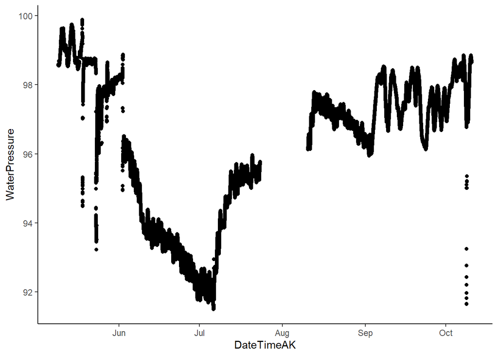

```r
strt.stream.one.2022.url <- "https://docs.google.com/spreadsheets/d/e/2PACX-1vS4XSmuumKD-j1aDhpA1gfyfrpqUiJUTuvcP9UGrgagvIrzlGYWk71hl0zAC8g8GHqOm1ONjWOpO_So/pub?output=csv" # WL
strt.stream.two.2022.url <- "https://docs.google.com/spreadsheets/d/e/2PACX-1vRhNn42-Jr1Y3aTFfMPiRxKrNZZjHeBBxkCmVcLVPQEKBf4qg_1Pw4nyUBr3mDwtEE8NKGIbS7kNSrS/pub?output=csv" #WR
strt.atmo.2022.url <- "https://docs.google.com/spreadsheets/d/e/2PACX-1vQxotkNZ6zyvUi51XOjNPumqSvwGfsZMJc7I6-QXBELHY7msBzAaqvEHV41A88Lt0I1Ga-l1343Q1cr/pub?output=csv"
# load in data
strt.stream.one.2022 <- read.csv(url(strt.stream.one.2022.url), skip = 1)
strt.stream.two.2022 <- read.csv(url(strt.stream.two.2022.url), skip = 1)
strt.atmo.2022 <- read.csv(url(strt.atmo.2022.url), skip = 1)

# clean for merging purposes
strt.stream.one.2022 <- strt.stream.one.2022[, -c(4,6:19)] # removing columns that arent date/abs pressure and temp

strt.stream.two.2022 <- strt.stream.two.2022[, -c(5:12)] # removing columns that arent date/abs pressure and temp

strt.atmo.2022 <- strt.atmo.2022[,-c(4:9)]

# changing to AK time (It reads in as GMT but it is actually AKST )
strt.stream.one.2022$DateTimeAK <- mdy_hms(strt.stream.one.2022$Date.Time..GMT.08.00)

strt.stream.two.2022$DateTimeAK <- mdy_hms(strt.stream.two.2022$Date.Time..GMT.08.00)
strt.atmo.2022$DateTimeAK <- mdy_hms(strt.atmo.2022$Date.Time..GMT.08.00)

strt.stream.two.2022$DateTimeAK <- force_tz(strt.stream.two.2022$DateTimeAK, tzone = "America/Anchorage")

strt.stream.one.2022$DateTimeAK <- force_tz(strt.stream.one.2022$DateTimeAK, tzone = "America/Anchorage")

strt.atmo.2022$DateTimeAK <- force_tz(strt.atmo.2022$DateTimeAK, tzone = "America/Anchorage")


# round date to 5 minute intervals
#strt.stream.one.2022$DateTimeAK <- lubridate::round_date(strt.stream.one.2022$DateTimeAK, "5 minutes")
#strt.stream.two.2022$DateTimeAK <- lubridate::round_date(strt.stream.two.2022$DateTimeAK, "5 minutes")

# cleaning off original datetime
strt.stream.one.2022 <- strt.stream.one.2022[, -c(2)] # removing columns that aren't date/abs pressure and temp
strt.stream.two.2022 <- strt.stream.two.2022[, -c(2)] # removing columns that arent
strt.atmo.2022 <- strt.atmo.2022[,-c(2)]

names(strt.stream.one.2022) <- c("Site","WaterPressure", "TempC", "DateTimeAK")

names(strt.stream.two.2022) <- c("Site","WaterPressure", "TempC", "DateTimeAK")

names(strt.atmo.2022) <- c("Site", "AirPressureSTRT", "DateTimeAK")

ggplot(strt.stream.one.2022, aes(x = DateTimeAK, y = WaterPressure))+
  geom_point() +
  theme_classic()
```

This is PT1 for STRT raw. Looking at how low the PT data is I am NOT going to trust this one and take it out of our analysis

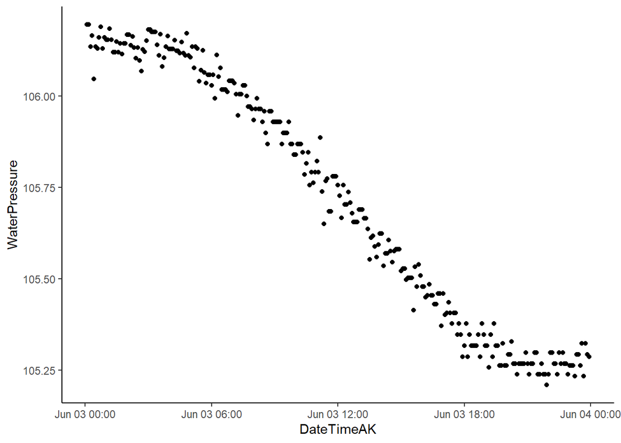

```r
strt.stream.two.2022 %>% filter(DateTimeAK > "2022-06-03" & DateTimeAK < "2022-06-04" ) %>% ggplot(aes(x = DateTimeAK, y = WaterPressure))+
  geom_point() +
  theme_classic()
```

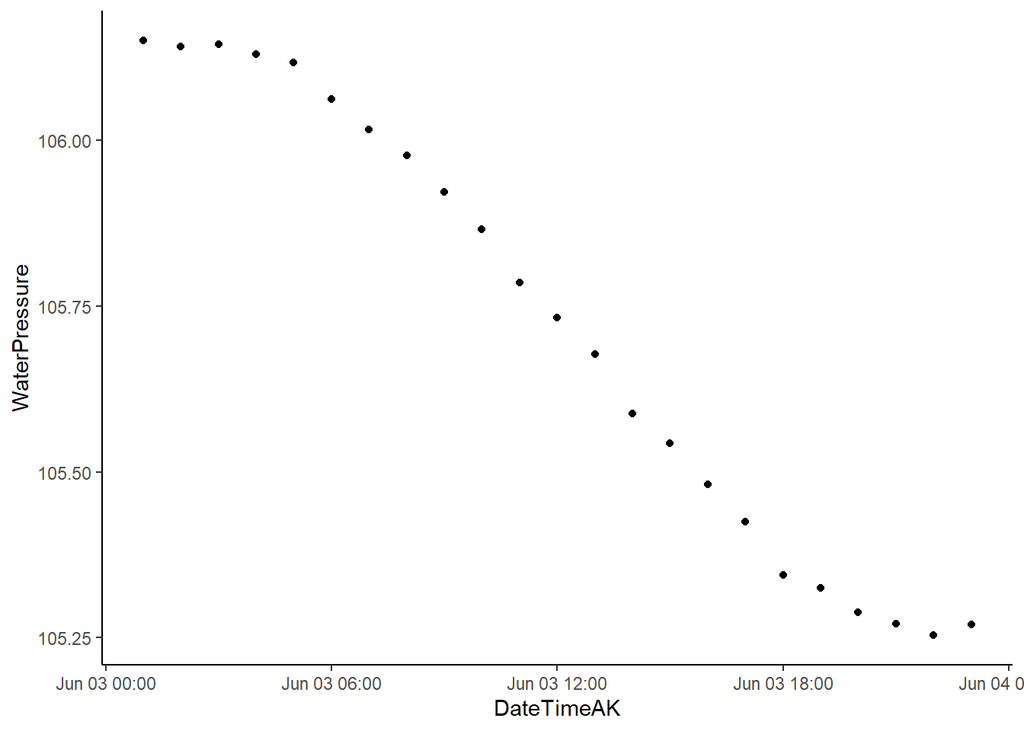

```r
# Take average at 60 min interval
strt.stream.two.2022$DateTimeAK <- lubridate::round_date(strt.stream.two.2022$DateTimeAK, "60 minutes")
# Take average pressure
strt.stream.two.2022 <- strt.stream.two.2022 %>% group_by(DateTimeAK) %>% summarise(DateTimeAK = unique(DateTimeAK), WaterPressure = mean(WaterPressure))

strt.stream.two.2022 %>% filter(DateTimeAK > "2022-06-03" & DateTimeAK < "2022-06-04" ) %>% ggplot(aes(x = DateTimeAK, y = WaterPressure))+
  geom_point() +
  theme_classic()
```

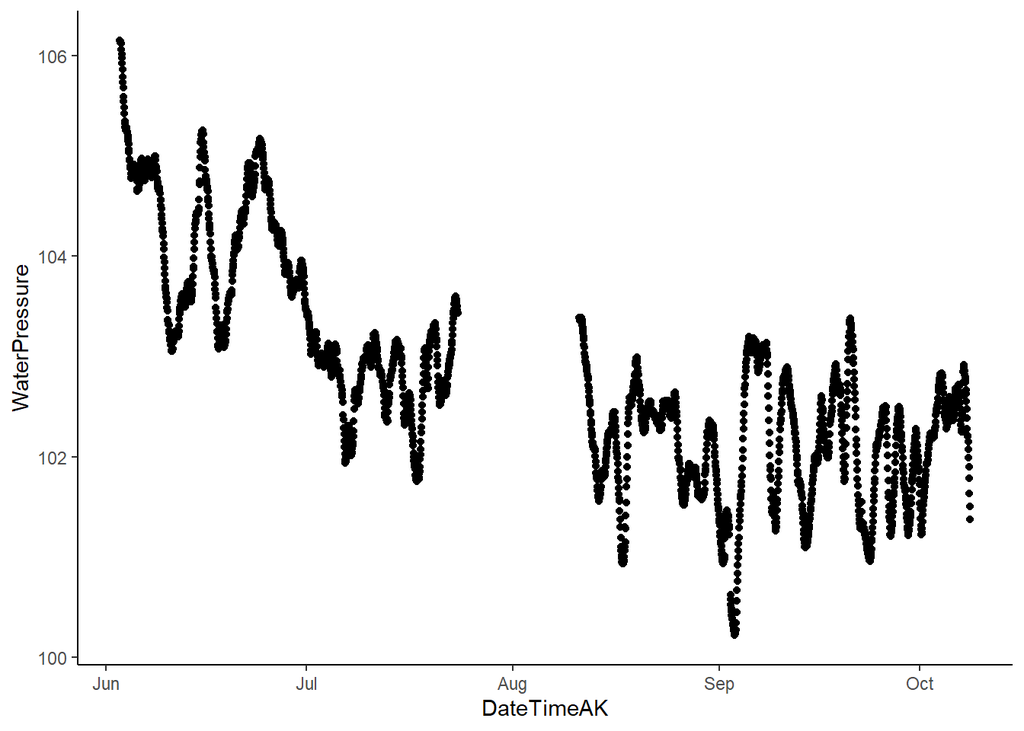

```r
#strt.stream.two.2022.b <- strt.stream.two.2022
#strt.stream.two.2022 <- strt.stream.two.2022.b

#adjusting/cleaning STRT 2
strt.stream.two.2022 <- strt.stream.two.2022 %>%
  mutate(across(c(WaterPressure),
                ~ifelse(DateTimeAK >= "2022-05-09" & DateTimeAK <= "2022-06-03", NA, .))) # PT wasnt placed into the stream until 6/3

strt.stream.two.2022 <- strt.stream.two.2022 %>%
  mutate(across(c(WaterPressure),
                ~ifelse(DateTimeAK >= "2022-05-09" & DateTimeAK <= "2022-10-03" &
      WaterPressure < 100, NA, .))) %>%
      filter(WaterPressure > 100)

strt.stream.two.2022 <- strt.stream.two.2022 %>% filter(DateTimeAK < "2022-08-01 00:00:00" | DateTimeAK > "2022-08-10 22:30:00")

strt.stream.two.2022 <- strt.stream.two.2022 %>%
  mutate(across(c(WaterPressure),
                ~ifelse(DateTimeAK >= "2022-08-15 12:00:00" & DateTimeAK <= "2022-08-17" & WaterPressure > 102.45, NA, .)))

strt.stream.two.2022 %>% #filter(DateTimeAK > "2022-10-01" & DateTimeAK < "2022-10-20" ) %>%
  ggplot(aes(x = DateTimeAK, y = WaterPressure))+
  geom_point() +
  theme_classic()
```

This looks better

```r
# merge to one
strt.final.pressure.2022 <- strt.stream.two.2022 # the first PT is crap
```